# `Trucks`

Truck Accidents Data

#### Desription

Data from a study in England in two periods from November 1969 to October 1971 and November 1971 to October 1973. A new compulsory safety measure for trucks was introduced in October 1971. Therefore, the question is whether the safety measure had an effect on the number of accidents and on the point of collision on the truck.

#### Usage

```
data("Trucks")
```

#### Format

A data frame with 24 observations on 5 variables. Freq frequency of accidents involving trucks. period factor indicating time period (before, after) 1971-11-01. collision factor indicating whether the collision was in the back or forward (including the front and the sides) of the truck (back, forward). parked factor indicating whether the truck was parked (yes, no). light factor indicating light conditions: day light (daylight), night on an illuminated road (night, illuminate), night on a dark road (night, dark).

#### Examples

```r
library(MASS)
data("Trucks")
tab <- xtabs(Freq ~ period + collision + light + parked, data = Trucks)
loglm(~ (collision + period) * parked * light, data = tab)
```

```
## Call:
## loglm(formula = ~(collision + period) * parked * light, data = tab)
##
## Statistics:
##                       X^2 df  P(> X^2)
## Likelihood Ratio 6.853404  6 0.3346175
## Pearson          6.972248  6 0.3234213
```

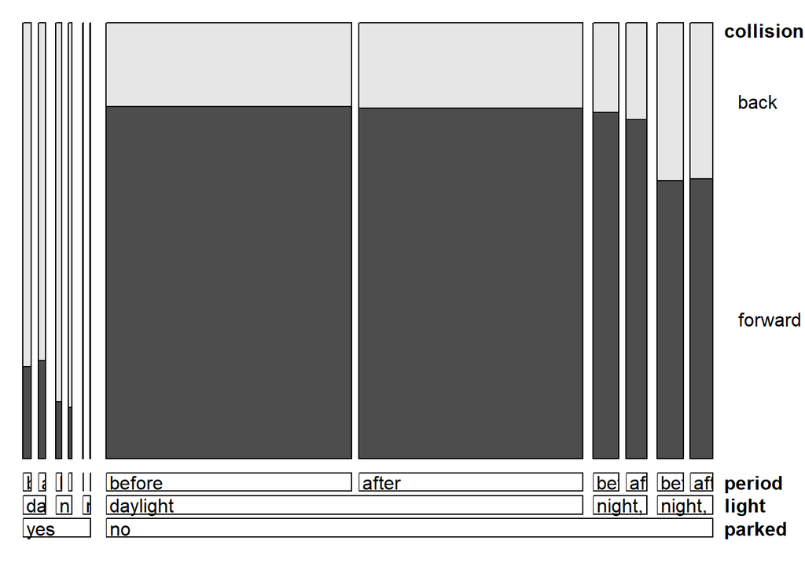

```r
doubledecker(collision ~ parked + light + period, data = tab)
```

[figure not shown]

```r
cotabplot(tab, panel = cotab_coindep)
```

Source E. B. Andersen (1991), The Statistical Analysis of Categorical Data, Table 6.8. References E. B. Andersen (1991), The Statistical Analysis of Categorical Data. 2nd edition. Springer-Verlag, Berlin.